# Learning Week 4: Indigenous health

PHRM3302 Tutorial

### Learning objectives for the week

Engage with Indigenous scholars to

1. Analyse the ways in which race, racialisation and racism are interpreted and employed within a health context
2. Evaluate the ways in which colonisation and structural racism influence the health and healthcare of Indigenous Australians

### Extend activities

- Review Cultural Safety in Practice Modules
- Bond and Singh, Closing the gap (Part 1) [ET]
- Conceptions of race and racism
- Bond and Singh, Closing the gap (Part 2) [ET]

### Incomplete History of Government Policy

| Date | Policy |
| --- | --- |
| 1788 | *Terra nullus* |
| 1901 | Federation. Commonwealth able to make laws for any race "other than the Aboriginal race". |
| 1901 ~ 1960s | State-based laws with the goals of segregation and assimilation (destruction). Includes missions and forcible removal of children from families. |
| 1967 | Referendum passed to change the constitution. Commonwealth able to pass laws in relation to Aboriginal and Torres Strait Islander peoples. |
| 1988--1992 | Mabo decision |
| 1990 | Reconciliation movement |
| 2007--2009 | UN Declaration on the Rights of Indigenous Peoples |
| 2007 | Close the Gap Campaign |
| 2017 | Uluru Statement from the Heart |

### Ahpra Code of conduct

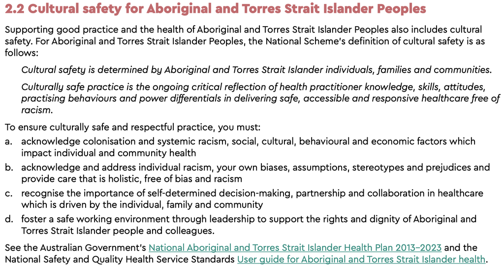

### Conceptions of racism

1. What is racism?
2. Identify the key components of an appropriate definition of racism.

*Prompts*

- Is there a concept of race without racism? (What is race?)
- Can there be racism in the absence of people with racist beliefs?
- Is “reverse racism” possible?

### C. J. Bond et al. (2020)

3. Draw two causal diagrams that seek explain the disparity observed in Indigenous health: (i) the causal diagram that C. J. Bond et al. (2020) is arguing *against*; (ii) the causal diagram that C. J. Bond et al. (2020) argues is more accurate.

> In the settler-colonial context contemporary racialised stereotypes principally draw on conceptions of Indigenous cultures, which serve as a euphemism for race (see Bond 2007; Moreton-Robinson 2016). This phenomenon can involve reconfiguring racist beliefs about racialised people as cultural or behavioural truths arising from group practices and choices—a phenomenon sometimes known as ‘cultural racism’ (Blaut 1992). While discussions about race necessarily involve conversations about power and racial hierarchies, addressing similar questions through a lens of culture can recode these as matters of simple difference and, in the case of Indigenous peoples, deficit or lack. The deviance and deficiencies of Indigenous people once ascribed to biological racial inferiority can be explained as the result of cultural factors and choices. Various inequalities can thus remain part of the natural order of things, not via biological notions of race, but through racialised imaginings of Indigenous cultural life (Bond, Macoun & Singh 2018).

C. Bond, Singh, and Kajlich (2019)

### Science is objective

4. Evaluate the following claim in terms of Indigenous health:

   > Epidemology is value-free

### References

Bond, Chelsea J, Lisa J Whop, David Singh, and Helena Kajlich. 2020. “‘Now We Say Black Lives Matter but … the Fact of the Matter Is, We Just Black Matter to Them’.” *Medical Journal of Australia* 213 (6): 248–250.e1. https://doi.org/10.5694/mja2.50727.

Bond, Chelsea, David Singh, and Helena Kajlich. 2019. “Canada-Australia Indigenous Health and Wellness Racism Working Group Discussion Paper and Literature Review.” Melbourne: Lowitja Institue. https://www.lowitja.org.au/content/Image/Canada_Australia_Discussion_Paper-web_hi_res.pdf.